# Project Template

Alan T. Arnholt

March 30, 2015

### Purpose of Study: (Note: This is the last paragraph of the research proposal used to remind the reader of the research objectives.)

The present study will examine young adults from the National Epidemiologic Survey of Alcohol and Related Conditions (NESARC). The goals of the analysis will include 1) establishing the relationship between major depression and nicotine dependence; and 2) determining whether or not the relationship between major depression and nicotine dependence exists above and beyond smoking quantity.

### Variables:

Variables from NESARC that will be used include: `MAJORDEPLIFE` (has subject experienced a major depression?), `CHECK321` (has subject smoked cigarettes in past 12 months?), `AGE` (age of subject), `TAB12MDX` (tobacco dependence past 12 months), `S3AQ3B1` (usual frequency when cigarettes smoked), `ETHRACE2A` (ethnicity of subject), `SEX` (gender of subject), and `S3AQ3C1` (usual smoking quantity of cigarettes when smoked). ￼

### Data Management

First, the data is placed on the search path using the `PDS` package. Next, a subset of people 25 or younger who smoked in the last 12 months is created using the `filter` function from `dplyr`. Note that `CHECK321 == 1` is used to see if subject has smoked in the past 12 months and `!is.na()` is used to make sure the subset does not contain `NA`s for the chosen variables. Last, the variables of interest are selected and stored in the data frame `nesarc.sub` using the `select` function from the `dplyr` package.

```r
library(PDS)
library(dplyr)
nesarc.sub <- NESARC %>%
  filter(!is.na(CHECK321) & !is.na(AGE) & CHECK321 ==1 & AGE <= 25)
dim(nesarc.sub)
```

```
[1] 1706 3008
```

```r
nesarc.sub <- nesarc.sub %>%
  select(MAJORDEPLIFE, CHECK321, AGE, TAB12MDX, S3AQ3B1, S3AQ3C1, ETHRACE2A, SEX)
dim(nesarc.sub)
```

```
[1] 1706    8
```

```r
summary(nesarc.sub)
```

```
 MAJORDEPLIFE CHECK321      AGE        TAB12MDX S3AQ3B1     S3AQ3C1
 0:1260       1:1706   Min.   :18.00   0:810    1:1320   Min.   : 1.0
 1: 446       2:   0   1st Qu.:20.00   1:896    2:  68   1st Qu.: 5.0
              9:   0   Median :22.00            3:  91   Median :10.0
                       Mean   :21.61            4:  88   Mean   :11.8
                       3rd Qu.:23.00            5:  65   3rd Qu.:20.0
                       Max.   :25.00            6:  71   Max.   :99.0
                                                9:   3
 ETHRACE2A SEX
 1:1060    1:856
 2: 211    2:850
 3:  42
 4:  58
 5: 335
```

Running `summary` on the `nesarc.sub` reveals some non-obvious categories for the factors `CHECK321` and `S3AQ3B1`. Reviewing the Code Book (HINT: Inside a pdf use `shift F` (Windows) or `command F` (Mac) then type the variable name inside the box to find the variable in the pdf), it is noted that a 9 is used to indicate missing values for `S3AQ3B1` and a 99 is used to indicate missing values for `S3AQ3C1`.

### Coding missing values

The variable `S3AQ3B1` uses a 9 to record `unknown` for smoking frequency and a 99 is used to record `unknown` for `S3AQ3C1`.

```r
nesarc.sub$S3AQ3B1[nesarc.sub$S3AQ3B1 == 9] <- NA
summary(nesarc.sub$S3AQ3B1)  # Note that 9 still appears
```

```
   1    2    3    4    5    6    9 NA's
1320   68   91   88   65   71    0    3
```

```r
nesarc.sub$S3AQ3B1 <- factor(nesarc.sub$S3AQ3B1)[, drop = TRUE]
summary(nesarc.sub$S3AQ3B1)  # Unused level no longer appears
```

```
   1    2    3    4    5    6 NA's
1320   68   91   88   65   71    3
```

```r
nesarc.sub$S3AQ3C1[nesarc.sub$S3AQ3C1 == 99] <- NA
summary(nesarc.sub$S3AQ3C1)
```

```
   Min. 1st Qu.  Median    Mean 3rd Qu.    Max.    NA's
   1.00    5.00   10.00   11.34   20.00   98.00       9
```

```r
nesarc.sub$CHECK321[nesarc.sub$CHECK321 == 9] <- NA
nesarc.sub$CHECK321 <- factor(nesarc.sub$CHECK321)[ , drop = TRUE]
summary(nesarc.sub)
```

```
 MAJORDEPLIFE CHECK321      AGE        TAB12MDX S3AQ3B1
 0:1260       1:1706   Min.   :18.00   0:810    1   :1320
 1: 446                1st Qu.:20.00   1:896    2   :  68
                       Median :22.00            3   :  91
                       Mean   :21.61            4   :  88
                       3rd Qu.:23.00            5   :  65
                       Max.   :25.00            6   :  71
                                                NA's:   3
    S3AQ3C1      ETHRACE2A SEX
 Min.   : 1.00   1:1060    1:856
 1st Qu.: 5.00   2: 211    2:850
 Median :10.00   3:  42
 Mean   :11.34   4:  58
 3rd Qu.:20.00   5: 335
 Max.   :98.00
 NA's   :9
```

### Creating New Variables

```r
nesarc.sub$DaysSmoke <- as.numeric(nesarc.sub$S3AQ3B1)
nesarc.sub$DaysSmoke[nesarc.sub$DaysSmoke == 1] <- 30
nesarc.sub$DaysSmoke[nesarc.sub$DaysSmoke == 2] <- 4*5.5
nesarc.sub$DaysSmoke[nesarc.sub$DaysSmoke == 3] <- 4*3.5
nesarc.sub$DaysSmoke[nesarc.sub$DaysSmoke == 4] <- 4*1.5
nesarc.sub$DaysSmoke[nesarc.sub$DaysSmoke == 5] <- 2.5
nesarc.sub$DaysSmoke[nesarc.sub$DaysSmoke == 6] <- 1
# Using dplyr again
nesarc.sub <- nesarc.sub %>%
  mutate(TotalCigsSmoked = DaysSmoke*S3AQ3C1)
proportions <- quantile(nesarc.sub$TotalCigsSmoked, na.rm = TRUE)
proportions
```

```
  0%  25%  50%  75% 100%
   1   90  300  600 2940
```

```r
nesarc.sub$CigsSmokedFac <- cut(nesarc.sub$TotalCigsSmoked, breaks = proportions, include.lowest = TRUE)
head(nesarc.sub)
```

```
  MAJORDEPLIFE CHECK321 AGE TAB12MDX S3AQ3B1 S3AQ3C1 ETHRACE2A SEX
1            0        1  25        1       1       3         2   2
2            1        1  21        1       2       3         5   1
3            1        1  24        1       1      10         1   2
4            1        1  23        1       1      10         1   2
5            0        1  21        0       1      20         1   1
6            1        1  23        0       1       5         1   2
  DaysSmoke TotalCigsSmoked CigsSmokedFac
1        30              90        [1,90]
2        22              66        [1,90]
3        30             300      (90,300]
4        30             300      (90,300]
5        30             600     (300,600]
6        30             150      (90,300]
```

### Labeling Variables

In the next section of code, variables are labeled and levels of factors are given informative labels. The order of the levels is also rearranged for the variables `S3AQ3B1`, `TAB12MDX`, and `SEX`.

```r
library(Hmisc)
label(nesarc.sub$TAB12MDX) <- "Tobacco Dependence past 12 Months"
label(nesarc.sub$CHECK321) <- "Smoked Cigarettes in the Past 12 Months"
label(nesarc.sub$S3AQ3B1) <- "Usual Smoking Frequency"
label(nesarc.sub$S3AQ3C1) <- "Usual Smoking Quantity"
nesarc.sub$MAJORDEPLIFE <- factor(nesarc.sub$MAJORDEPLIFE,
                              labels = c("No Depression", "Yes Depression"))
nesarc.sub$S3AQ3B1 <- factor(nesarc.sub$S3AQ3B1,
                         labels = c("Every Day", "5 to 6 Days/week",
                                    "3 to 4 Days/week",   "1 to 2 Days/week",
                                    "2 to 3 Days/month",
                                    "Once a month or less"))
nesarc.sub$S3AQ3B1 <- factor(nesarc.sub$S3AQ3B1,
                         levels = c("Once a month or less", "2 to 3 Days/month",
                                    "1 to 2 Days/week",  "3 to 4 Days/week",
                                    "5 to 6 Days/week", "Every Day"))
nesarc.sub$TAB12MDX <- factor(nesarc.sub$TAB12MDX,
                         labels = c("No Nicotine Dependence", "Nicotine Dependence"))
nesarc.sub$TAB12MDX <- factor(nesarc.sub$TAB12MDX,
                         levels = c("Nicotine Dependence", "No Nicotine Dependence"))
nesarc.sub$ETHRACE2A <- factor(nesarc.sub$ETHRACE2A,
                               labels = c("Caucasian", "African American",
                                          "Native American", "Asian", "Hispanic"))
nesarc.sub$SEX <- factor(nesarc.sub$SEX, labels = c("Male", "Female"))
table(nesarc.sub$SEX)
```

```
  Male Female
   856    850
```

```r
nesarc.sub$SEX <- factor(nesarc.sub$SEX, levels = c("Female", "Male"))
summary(nesarc.sub)
```

```
         MAJORDEPLIFE  CHECK321      AGE
 No Depression :1260   1:1706   Min.   :18.00
 Yes Depression: 446            1st Qu.:20.00
                                Median :22.00
                                Mean   :21.61
                                3rd Qu.:23.00
                                Max.   :25.00

                   TAB12MDX                   S3AQ3B1        S3AQ3C1
 Nicotine Dependence   :896   Once a month or less:  71   Min.   : 1.00
 No Nicotine Dependence:810   2 to 3 Days/month   :  65   1st Qu.: 5.00
                              1 to 2 Days/week    :  88   Median :10.00
                              3 to 4 Days/week    :  91   Mean   :11.34
                              5 to 6 Days/week    :  68   3rd Qu.:20.00
                              Every Day           :1320   Max.   :98.00
                              NA's                :   3   NA's   :9
            ETHRACE2A        SEX        DaysSmoke     TotalCigsSmoked
 Caucasian       :1060   Female:850   Min.   : 1.00   Min.   :   1.0
 African American: 211   Male  :856   1st Qu.:30.00   1st Qu.:  90.0
 Native American :  42                Median :30.00   Median : 300.0
 Asian           :  58                Mean   :25.07   Mean   : 319.4
 Hispanic        : 335                3rd Qu.:30.00   3rd Qu.: 600.0
                                      Max.   :30.00   Max.   :2940.0
                                      NA's   :3       NA's   :9
        CigsSmokedFac
 [1,90]        :429
 (90,300]      :678
 (300,600]     :503
 (600,2.94e+03]: 87
 NA's          :  9
```

### Renaming Variables

```r
nesarc.sub <- nesarc.sub %>%
  rename(Depression = MAJORDEPLIFE, TobaccoDependence = TAB12MDX,
         SmokingFreq = S3AQ3B1, DailyCigsSmoked = S3AQ3C1, Ethnicity = ETHRACE2A,
         Sex = SEX, Age = AGE)
head(nesarc.sub)
```

```
      Depression CHECK321 Age      TobaccoDependence      SmokingFreq
1  No Depression        1  25    Nicotine Dependence        Every Day
2 Yes Depression        1  21    Nicotine Dependence 5 to 6 Days/week
3 Yes Depression        1  24    Nicotine Dependence        Every Day
4 Yes Depression        1  23    Nicotine Dependence        Every Day
5  No Depression        1  21 No Nicotine Dependence        Every Day
6 Yes Depression        1  23 No Nicotine Dependence        Every Day
  DailyCigsSmoked        Ethnicity    Sex DaysSmoke TotalCigsSmoked
1               3 African American Female        30              90
2               3         Hispanic   Male        22              66
3              10        Caucasian Female        30             300
4              10        Caucasian Female        30             300
5              20        Caucasian   Male        30             600
6               5        Caucasian Female        30             150
  CigsSmokedFac
1        [1,90]
2        [1,90]
3      (90,300]
4      (90,300]
5     (300,600]
6      (90,300]
```

### Creating Tables

Basic tables can be created using the functions `table` or `xtabs`. Frequency tables are created for the variables `TobaccoDependence`, `CigsSmokedFac`, and `SmokingFreq`.

```r
T1 <- xtabs(~TobaccoDependence, data = nesarc.sub)
T2 <- xtabs(~CigsSmokedFac, data = nesarc.sub)
T3 <- xtabs(~SmokingFreq, data = nesarc.sub)
table(nesarc.sub$TobaccoDependence)
```

```
   Nicotine Dependence No Nicotine Dependence
                   896                    810
```

```r
T1
```

```
TobaccoDependence
   Nicotine Dependence No Nicotine Dependence
                   896                    810
```

```r
T2
```

```
CigsSmokedFac
        [1,90]       (90,300]      (300,600] (600,2.94e+03]
           429            678            503             87
```

```r
T3
```

```
SmokingFreq
Once a month or less    2 to 3 Days/month     1 to 2 Days/week
                  71                   65                   88
    3 to 4 Days/week     5 to 6 Days/week            Every Day
                  91                   68                 1320
```

In the data frame `nesarc.sub`, there are 896 nicotine dependent subjects and 810 subjects that are not nicotine dependent. A small number of smokers (87) smoke over 600 cigarettes per month. Most of the subjects in `nesarc.sub` are daily smokers (1320) with the remainder distributed uniformly across the first five levels of `SmokingFreq`.

### Graphing Frequency Tables

The barplots are all created with the package `ggplot2`. The barplots start with the defaults for the `geom_bar` and add more detail to the plot with each graph.

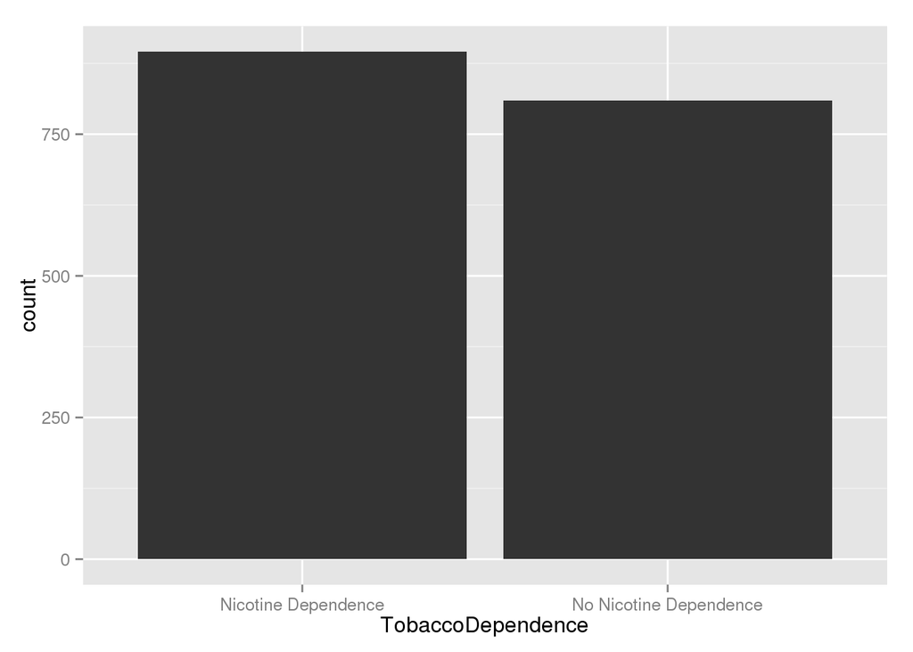

```r
library(ggplot2)
g1 <- ggplot(data = nesarc.sub, aes(x = TobaccoDependence)) +
  geom_bar()
g1
```

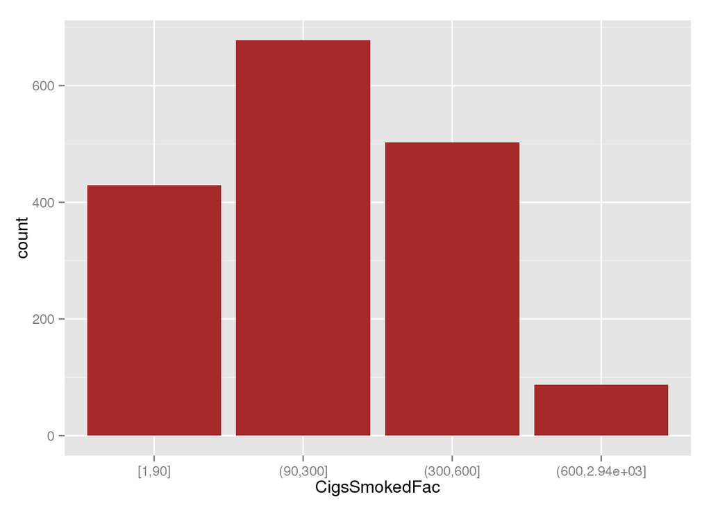

```r
g2 <- ggplot(data = na.omit(nesarc.sub), aes(x = CigsSmokedFac)) +
  geom_bar(fill = "brown")
g2
```

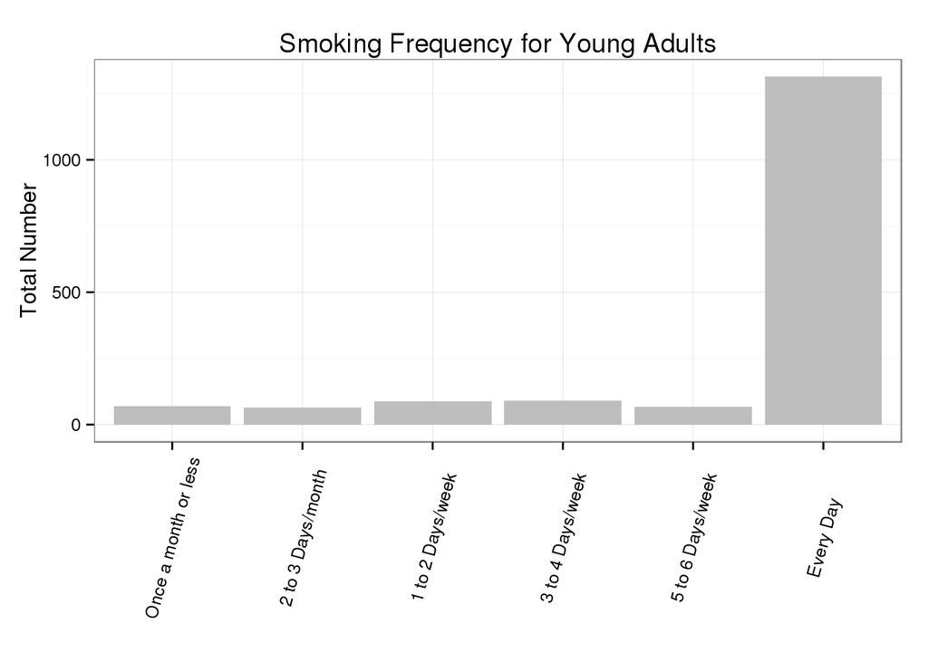

```r
g3 <- ggplot(data = na.omit(nesarc.sub), aes(SmokingFreq)) +
  geom_bar(fill = "gray") +
  labs(x = "", y = "Total Number", title = "Smoking Frequency for Young Adults") +
  theme_bw() +
  theme(axis.text.x  = element_text(angle = 75, vjust = 0.5))
g3
```

### Graphing Numeric Variables

One popular way to graph a continuous variable is to use a histogram. `R` has the base function `hist` which can be used for this purpose. We will also use the package `ggplot2` to create histograms. We start with a basic histogram of the variable `TotalCigsSmoked`.

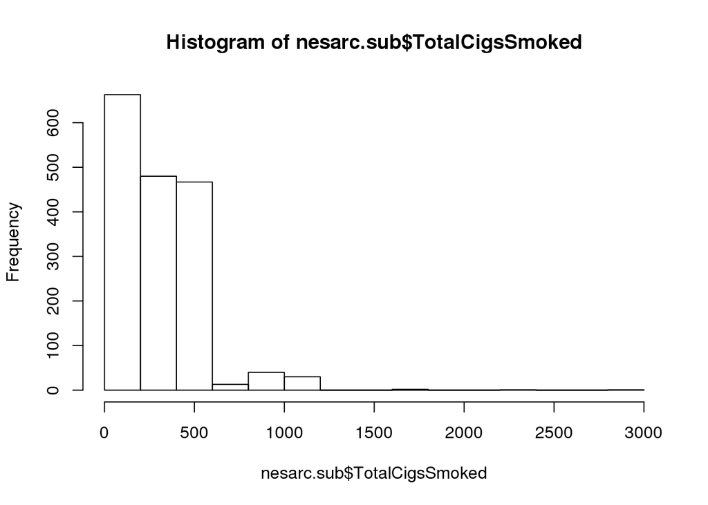

```r
hist(nesarc.sub$TotalCigsSmoked)
```

Experiment with the code in the previous code chunk to change the color, the title, and if needed the labels on the $x$- and $y$-axes.

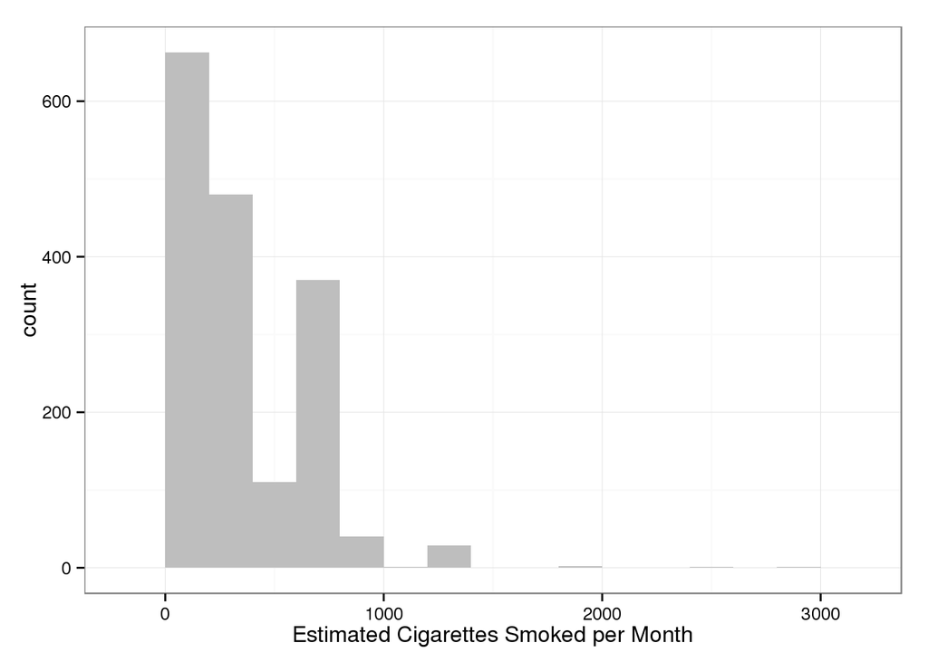

```r
ggplot(data = nesarc.sub, aes(x = TotalCigsSmoked)) +
  geom_histogram(binwidth = 200, fill = "gray") +
  labs(x = "Estimated Cigarettes Smoked per Month") +
  theme_bw()
```

### Creating Density Plots

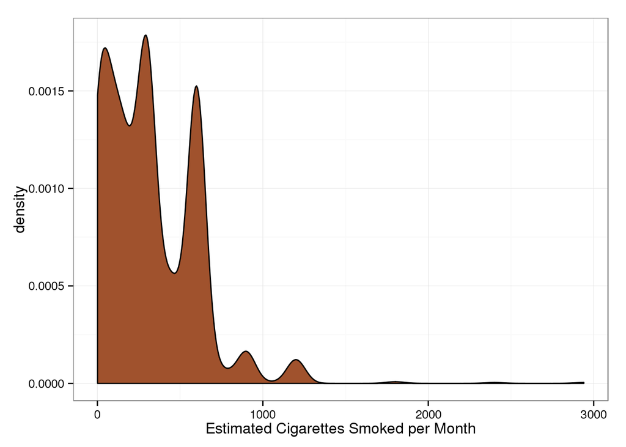

```r
ggplot(data = nesarc.sub, aes(x = TotalCigsSmoked)) +
  geom_density(fill = "sienna") +
  labs(x = "Estimated Cigarettes Smoked per Month") +
  theme_bw()
```

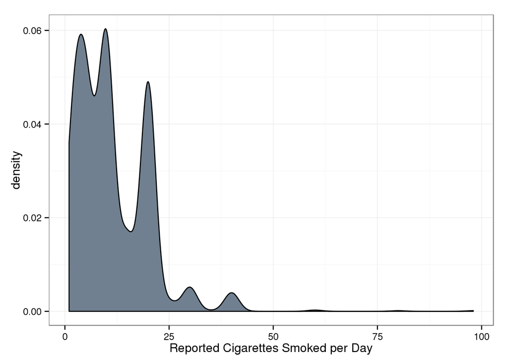

```r
ggplot(data = nesarc.sub, aes(x = DailyCigsSmoked)) +
  geom_density(fill = "slategrey") +
  labs(x = "Reported Cigarettes Smoked per Day") +
  theme_bw()
```

### The 3 S’s

```r
summary(nesarc.sub$TotalCigsSmoked)
```

```
   Min. 1st Qu.  Median    Mean 3rd Qu.    Max.    NA's
    1.0    90.0   300.0   319.4   600.0  2940.0       9
```

```r
fivenum(nesarc.sub$TotalCigsSmoked)
```

```
[1]    1   90  300  600 2940
```

```r
median(nesarc.sub$TotalCigsSmoked, na.rm = TRUE)
```

```
[1] 300
```

```r
IQR(nesarc.sub$TotalCigsSmoked, na.rm = TRUE)
```

```
[1] 510
```

The `shape` of the distribution for the estimated cigarettes smoked per month is skewed to the right. The `center` (median) of the distribution is 300 and the `spread` (interquartile range) for the distribution is 510.

### Bivariate Graphs (C $\rightarrow$ C)

Consider using depression status (`Depression`) to predict nicotine dependence (`TobaccoDependence`).

```r
T1 <- xtabs(~ TobaccoDependence + Depression, data = nesarc.sub)
T1
```

```
                        Depression
TobaccoDependence        No Depression Yes Depression
  Nicotine Dependence              574            322
  No Nicotine Dependence           686            124
```

```r
T2 <- prop.table(T1, 2)
T2
```

```
                        Depression
TobaccoDependence        No Depression Yes Depression
  Nicotine Dependence        0.4555556      0.7219731
  No Nicotine Dependence     0.5444444      0.2780269
```

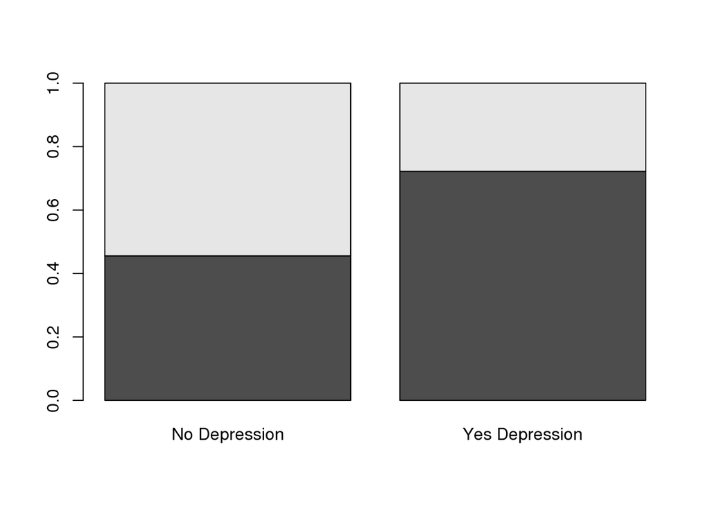

```r
barplot(T2)
```

The last graph needs a legend as well as a title. While it is possible to construct a legend and title for the last graph, it is much better to use an approach that will generate the legend automatically.

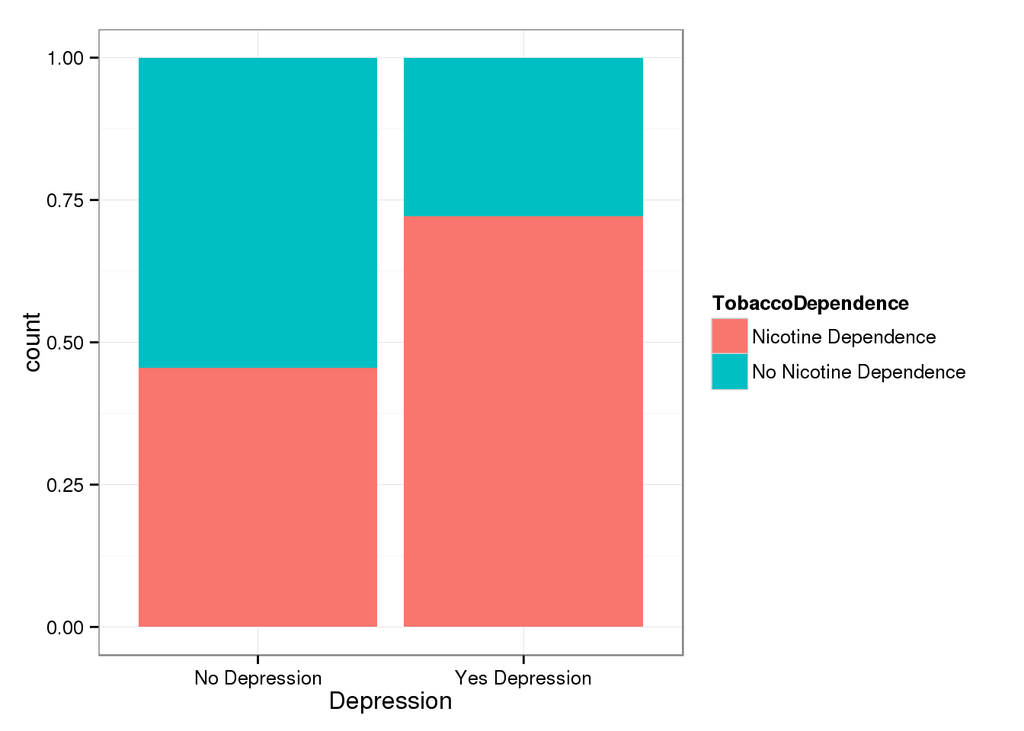

```r
g1 <- ggplot(data = nesarc.sub, aes(x = Depression, fill = TobaccoDependence)) +
  geom_bar(position = "fill") +
  theme_bw()
g1
```

Tweaking the last graph.

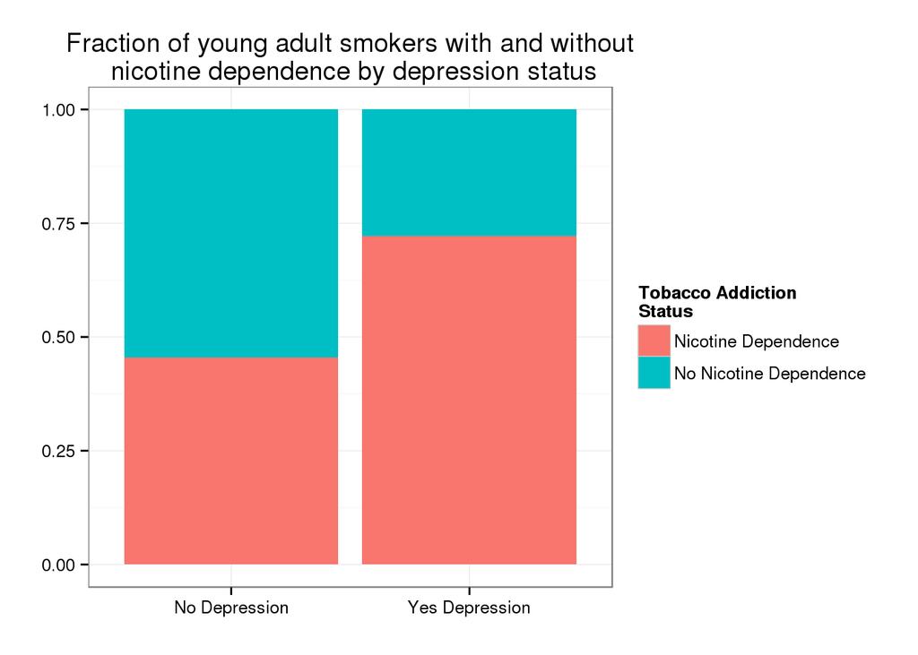

```r
g1 + labs(x = "", y = "",
          title = "Fraction of young adult smokers with and without\n nicotine dependence by depression status") +
  scale_fill_discrete(name="Tobacco Addiction\nStatus")
```

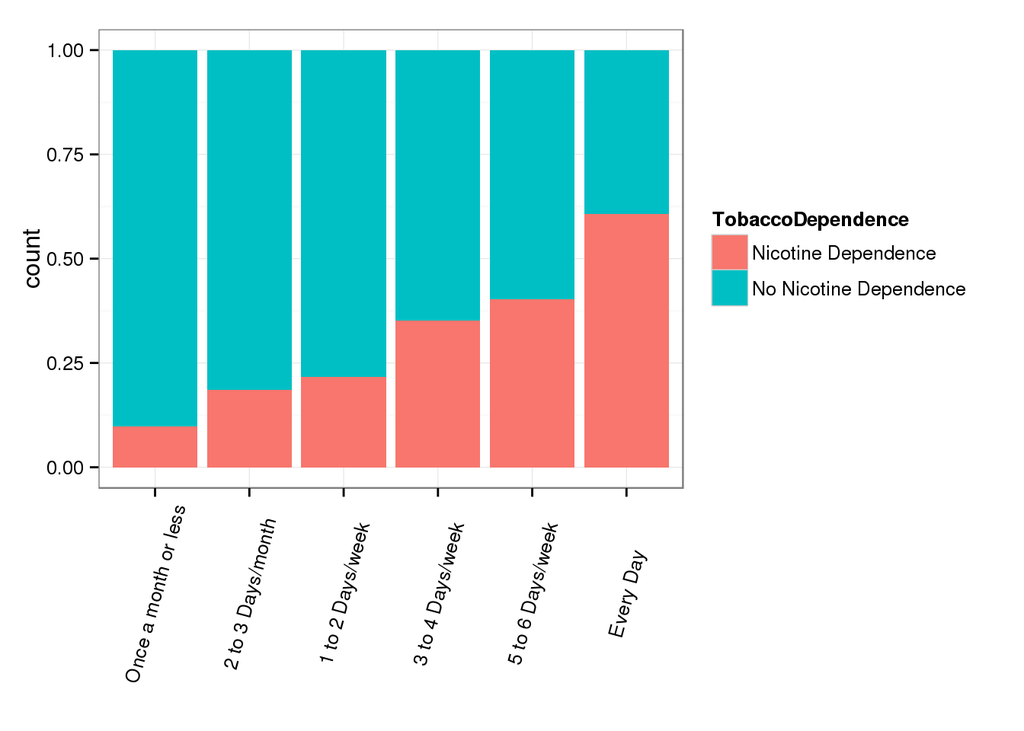

```r
g2 <- ggplot(data = na.omit(nesarc.sub), aes(x = SmokingFreq, fill = TobaccoDependence)) +
  geom_bar(position = "fill") +
  theme_bw() +
  theme(axis.text.x  = element_text(angle = 75, vjust = 0.5)) +
  labs(x = "")
g2
```

```r
 g3 <- g2 + facet_grid(Sex ~ .) +
  theme(axis.text.x  = element_text(angle = 85, vjust = 0.5)) +
  labs(x = "", y = "", title = "Fraction of young adult smokers with and without\n nicotine dependence by smoking frequency") +
  scale_fill_discrete(name="Tobacco Addiction\nStatus")
 g3
```

[figure not shown]

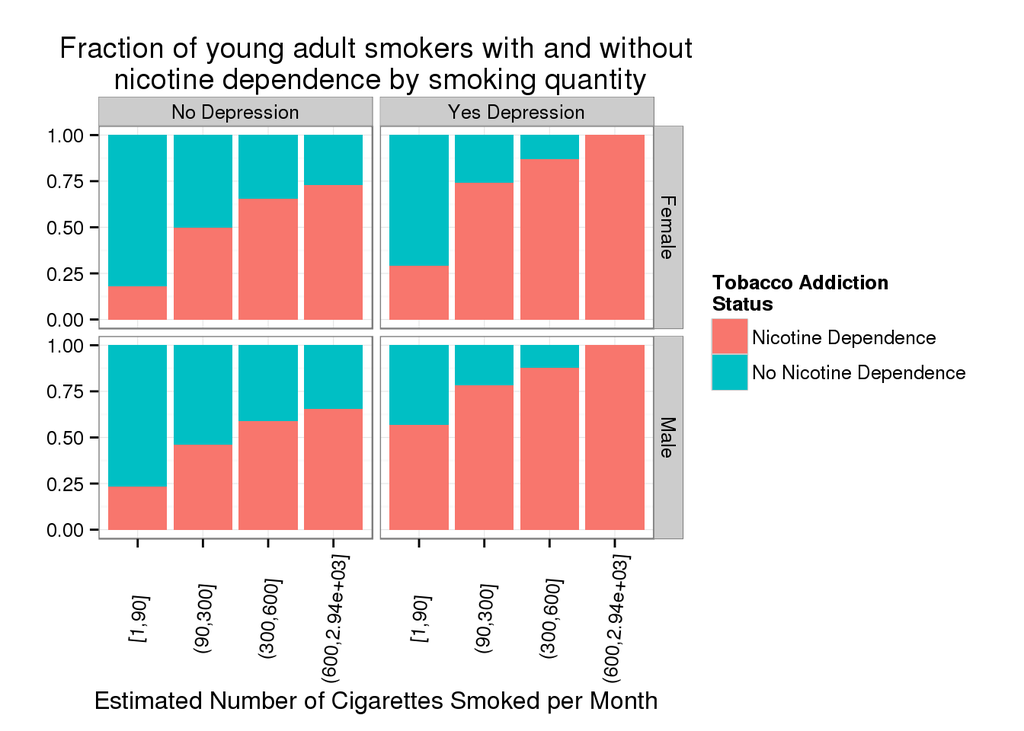

```r
ggplot(data = na.omit(nesarc.sub), aes(x = CigsSmokedFac, fill = TobaccoDependence)) +
  geom_bar(position = "fill") +
  theme_bw() + facet_grid(Sex ~ Depression) +
  theme(axis.text.x  = element_text(angle = 85, vjust = 0.5)) +
  labs(x = "Estimated Number of Cigarettes Smoked per Month", y = "", title = "Fraction of young adult smokers with and without\n nicotine dependence by smoking quantity") +
  scale_fill_discrete(name="Tobacco Addiction\nStatus")
```

### Using Mosaic Plots

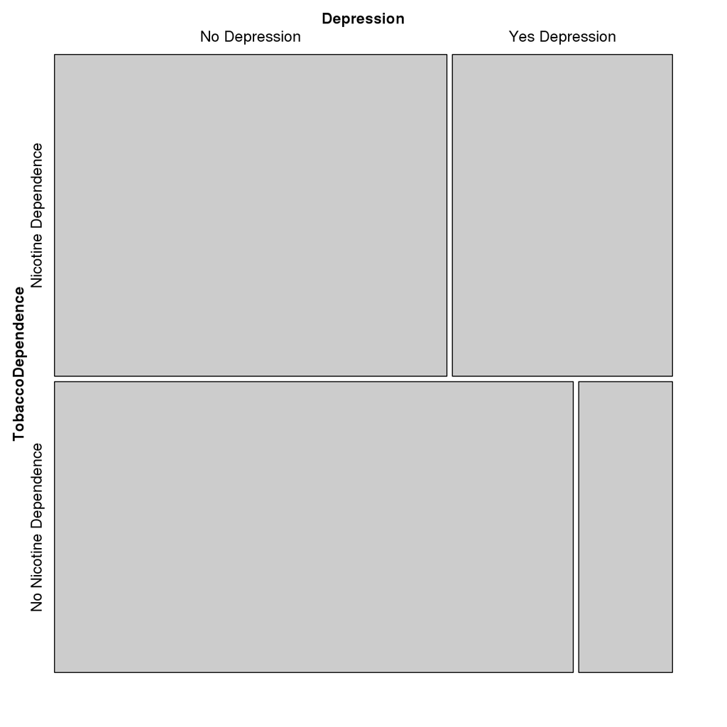

```r
library(vcd)
mosaic(~TobaccoDependence + Depression, data = nesarc.sub)
```

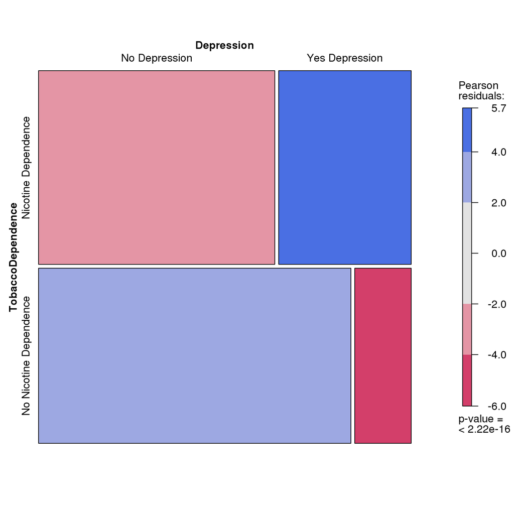

```r
mosaic(~TobaccoDependence + Depression, data = nesarc.sub, shade = TRUE)
```

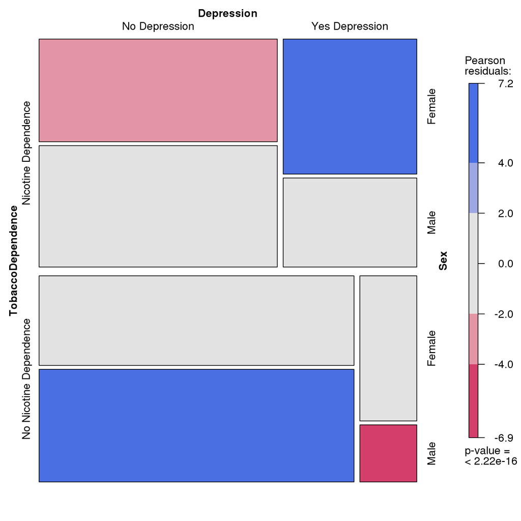

```r
mosaic(~TobaccoDependence + Depression + Sex, data = nesarc.sub, shade = TRUE)
```

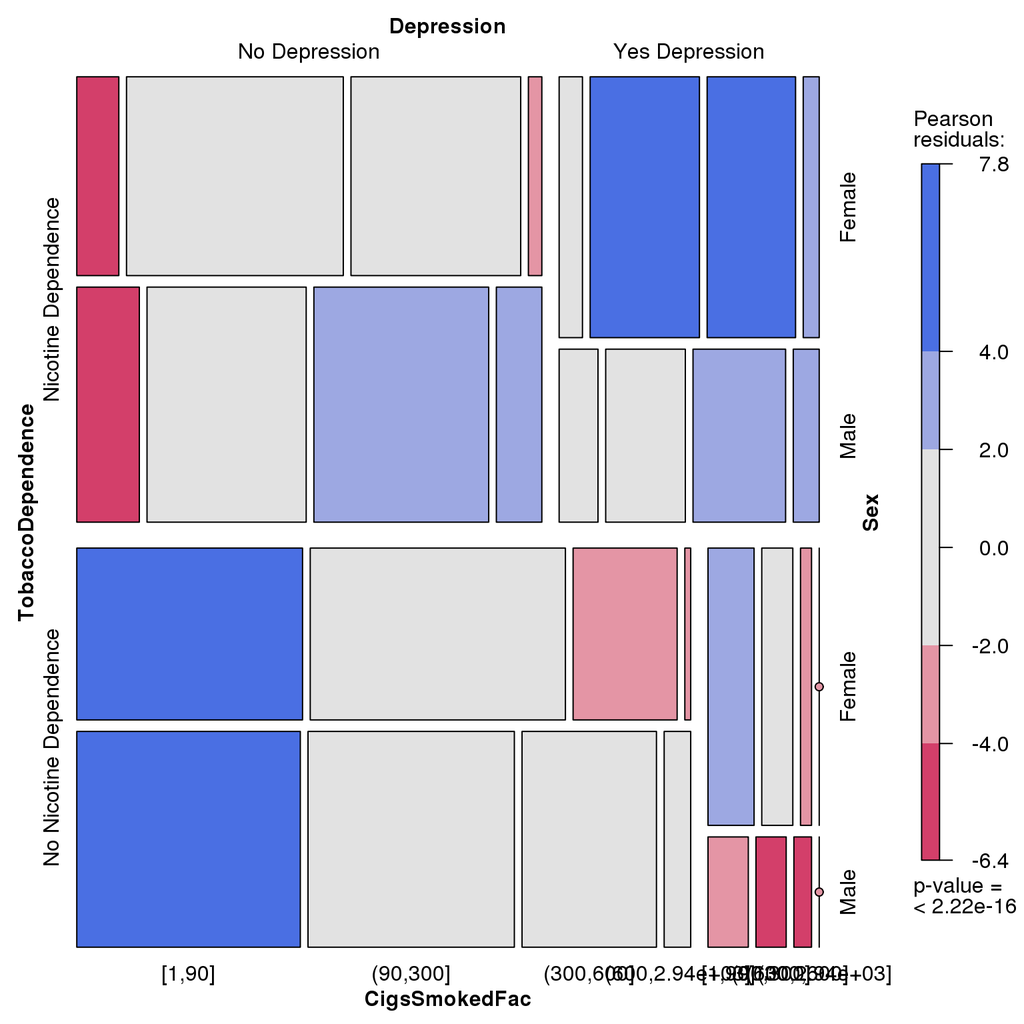

```r
mosaic(~TobaccoDependence + Depression + Sex + CigsSmokedFac, data = nesarc.sub, shade = TRUE)
```

### Some Statistics

Note `nesarc.sub` is not the same data set discussed in the book. In the book, the subset is smaller since it includes only people who have smoked every day (`S3AQ41`). This subset has $(n = 1706)$ compared to the one in the book which has $n = 1320$.

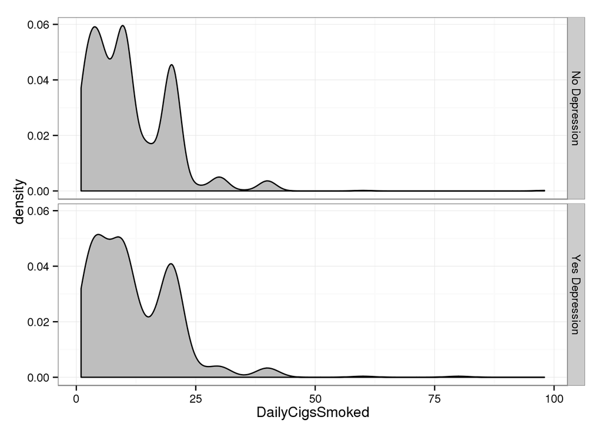

```r
ggplot(data = nesarc.sub, aes(x = DailyCigsSmoked)) +
   geom_density(fill = "gray") +
   facet_grid(Depression~.) +
   theme_bw()
```

```r
tapply(nesarc.sub$DailyCigsSmoked, list(nesarc.sub$Depression), sd, na.rm = TRUE)
```

```
 No Depression Yes Depression
      8.545279       9.172743
```

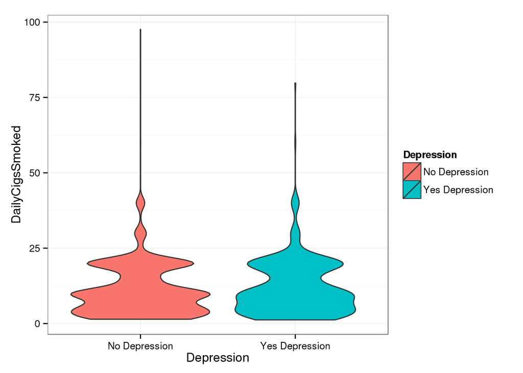

```r
 ggplot(data = nesarc.sub, aes(x = Depression, y = DailyCigsSmoked, fill = Depression)) + geom_violin() +
   theme_bw()
```

```r
t.test(DailyCigsSmoked ~ Depression, data = nesarc.sub)
```

```
    Welch Two Sample t-test

data:  DailyCigsSmoked by Depression
t = -1.7158, df = 732.84, p-value = 0.08663
alternative hypothesis: true difference in means is not equal to 0
95 percent confidence interval:
 -1.8312941  0.1231774
sample estimates:
 mean in group No Depression mean in group Yes Depression
                    11.11891                     11.97297
```

```r
t.test(TotalCigsSmoked ~ Depression, data = nesarc.sub)
```

```
    Welch Two Sample t-test

data:  TotalCigsSmoked by Depression
t = -1.8353, df = 734.09, p-value = 0.06686
alternative hypothesis: true difference in means is not equal to 0
95 percent confidence interval:
 -59.652230   2.007771
sample estimates:
 mean in group No Depression mean in group Yes Depression
                    311.8771                     340.6993
```

```r
t.test(TotalCigsSmoked ~ Depression, data = nesarc.sub, var.equal = TRUE) # assumptions not really met here
```

```
    Two Sample t-test

data:  TotalCigsSmoked by Depression
t = -1.8965, df = 1695, p-value = 0.05807
alternative hypothesis: true difference in means is not equal to 0
95 percent confidence interval:
 -58.6306829   0.9862242
sample estimates:
 mean in group No Depression mean in group Yes Depression
                    311.8771                     340.6993
```

```r
summary(aov(TotalCigsSmoked ~ Depression, data = nesarc.sub))
```

```
              Df    Sum Sq Mean Sq F value Pr(>F)
Depression     1    272337  272337   3.597 0.0581 .
Residuals   1695 128346537   75721
---
Signif. codes:  0 '***' 0.001 '**' 0.01 '*' 0.05 '.' 0.1 ' ' 1
9 observations deleted due to missingness
```

```r
# OR
mod <- lm(TotalCigsSmoked ~ Depression, data = nesarc.sub)
anova(mod)
```

```
Analysis of Variance Table

Response: TotalCigsSmoked
             Df    Sum Sq Mean Sq F value  Pr(>F)
Depression    1    272337  272337  3.5966 0.05807 .
Residuals  1695 128346537   75721
---
Signif. codes:  0 '***' 0.001 '**' 0.01 '*' 0.05 '.' 0.1 ' ' 1
```

### Taking a permuation approach

You should add your own notes here when I explain this in class.

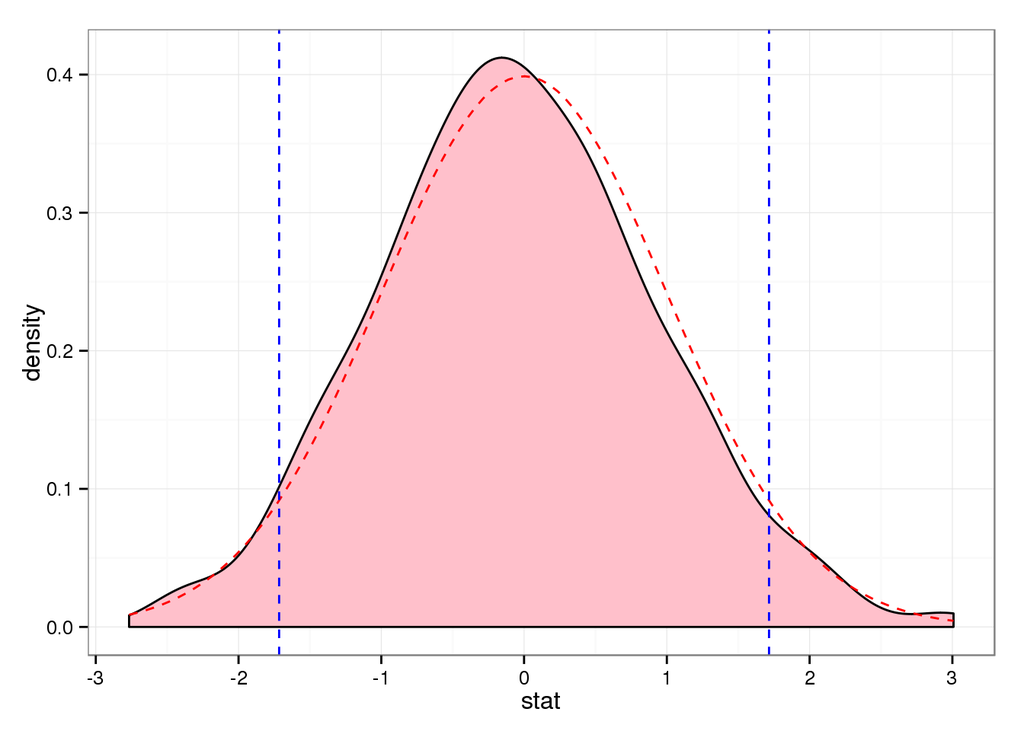

```r
set.seed(123)
SIMS <- 1000 - 1
stat <- numeric(SIMS)
TS <- t.test(DailyCigsSmoked ~ Depression, data = nesarc.sub)$stat
for(i in 1:SIMS){
  stat[i] <- t.test(DailyCigsSmoked ~ sample(Depression), data = nesarc.sub)$stat
}
ggplot(data = data.frame(stat = stat), aes(x = stat)) +
  geom_density(fill = "pink") +
  theme_bw() +
  stat_function(fun = dt, arg = list(df = 733), color = "red", linetype = "dashed") + geom_vline(x = c(TS, -TS), linetype = "dashed", color = "blue")
```

```r
TS
```

```
        t
-1.715751
```

```r
pv <- (sum(stat >= abs(TS))*2 + 1) / SIMS
pv
```

```
[1] 0.08308308
```

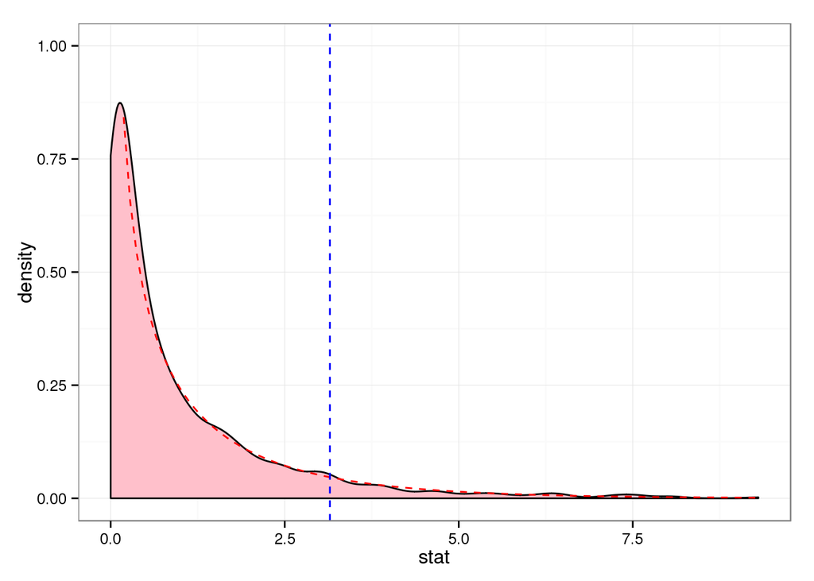

```r
# ANOVA
set.seed(123)
SIMS <- 1000 - 1
stat <- numeric(SIMS)
TSF <- anova(lm(DailyCigsSmoked ~ Depression, data = nesarc.sub))[1, 4]
for(i in 1:SIMS){
  stat[i] <- anova(lm(DailyCigsSmoked ~ sample(Depression), data = nesarc.sub))[1, 4]
}
ggplot(data = data.frame(stat = stat), aes(x = stat)) +
  geom_density(fill = "pink") +
  theme_bw() +
  stat_function(fun = df, arg = list(df1 = 1, df2 = 1695), color = "red", linetype = "dashed") + geom_vline(x = TSF, linetype = "dashed", color = "blue") + ylim(0, 1)
```

```r
TSF
```

```
[1] 3.149407
```

```r
pvF <- (sum(stat >= TSF) + 1) / SIMS
pvF
```

```
[1] 0.07007007
```

## Another Example

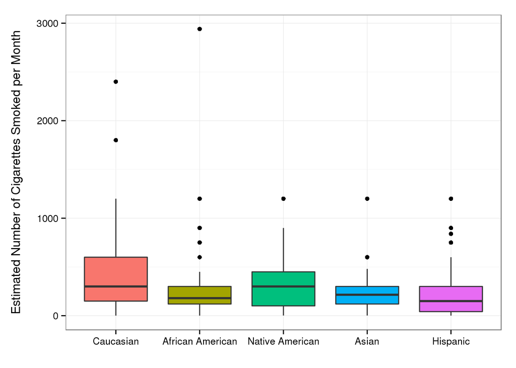

```r
ggplot(data = nesarc.sub, aes(x = Ethnicity, y = TotalCigsSmoked, fill = Ethnicity)) +
  geom_boxplot() +
  guides(fill = FALSE) +
  theme_bw() +
  labs(x = "", y = "Estimated Number of Cigarettes Smoked per Month\n")
```

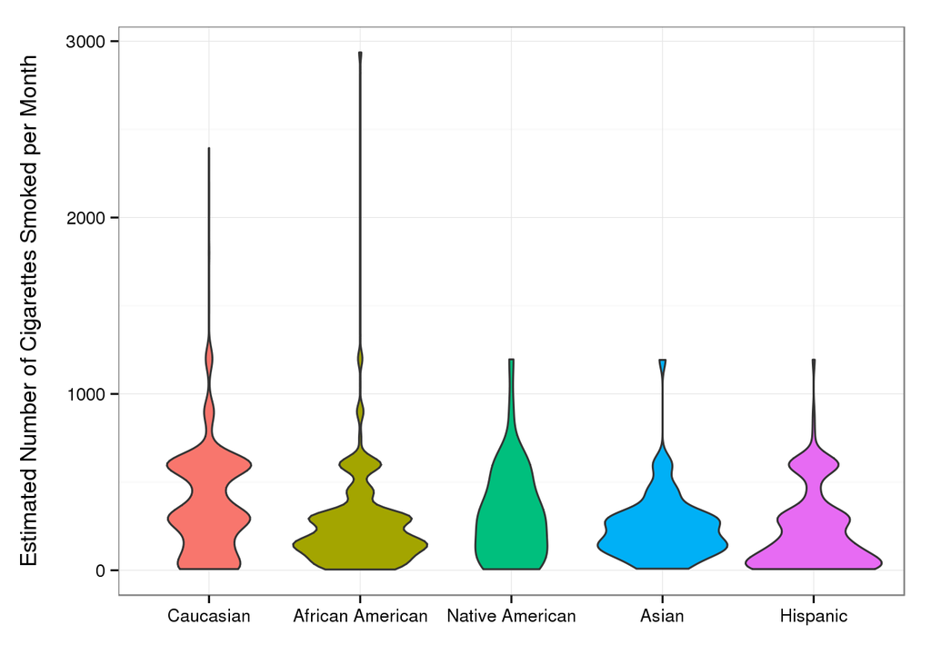

```r
ggplot(data = nesarc.sub, aes(x = Ethnicity, y = TotalCigsSmoked, fill = Ethnicity)) +
  geom_violin() +
  guides(fill = FALSE) +
  theme_bw() +
  labs(x = "", y = "Estimated Number of Cigarettes Smoked per Month\n")
```

$H_0:\mu_{\text{Caucassian}} = \mu_{\text{African American}}=\mu_{\text{Native American}} =\mu_{\text{Asian}} =\mu_{\text{Hispanic}}$ versus $H_1:\mu_{i} \neq \mu_{j}$ for some $(i, j)$.

```r
eth.aov <- aov(TotalCigsSmoked ~ Ethnicity, data = nesarc.sub)
summary(eth.aov)
```

```
              Df    Sum Sq Mean Sq F value Pr(>F)
Ethnicity      4   7012102 1753026   24.39 <2e-16 ***
Residuals   1692 121606772   71872
---
Signif. codes:  0 '***' 0.001 '**' 0.01 '*' 0.05 '.' 0.1 ' ' 1
9 observations deleted due to missingness
```

```r
CIs <- TukeyHSD(eth.aov)
CIs
```

```
  Tukey multiple comparisons of means
    95% family-wise confidence level

Fit: aov(formula = TotalCigsSmoked ~ Ethnicity, data = nesarc.sub)

$Ethnicity
                                       diff        lwr        upr
African American-Caucasian       -110.06777 -165.38997  -54.74558
Native American-Caucasian         -58.90587 -174.09624   56.28450
Asian-Caucasian                  -123.96375 -222.69939  -25.22811
Hispanic-Caucasian               -149.57543 -195.59596 -103.55490
Native American-African American   51.16190  -72.58143  174.90524
Asian-African American            -13.89598 -122.48842   94.69646
Hispanic-African American         -39.50766 -104.01720   25.00189
Asian-Native American             -65.05788 -213.38385   83.26809
Hispanic-Native American          -90.66956 -210.54348   29.20436
Hispanic-Asian                    -25.61168 -129.77339   78.55003
                                     p adj
African American-Caucasian       0.0000006
Native American-Caucasian        0.6300505
Asian-Caucasian                  0.0056089
Hispanic-Caucasian               0.0000000
Native American-African American 0.7911826
Asian-African American           0.9968050
Hispanic-African American        0.4514196
Asian-Native American            0.7527322
Hispanic-Native American         0.2356840
Hispanic-Asian                   0.9625311
```

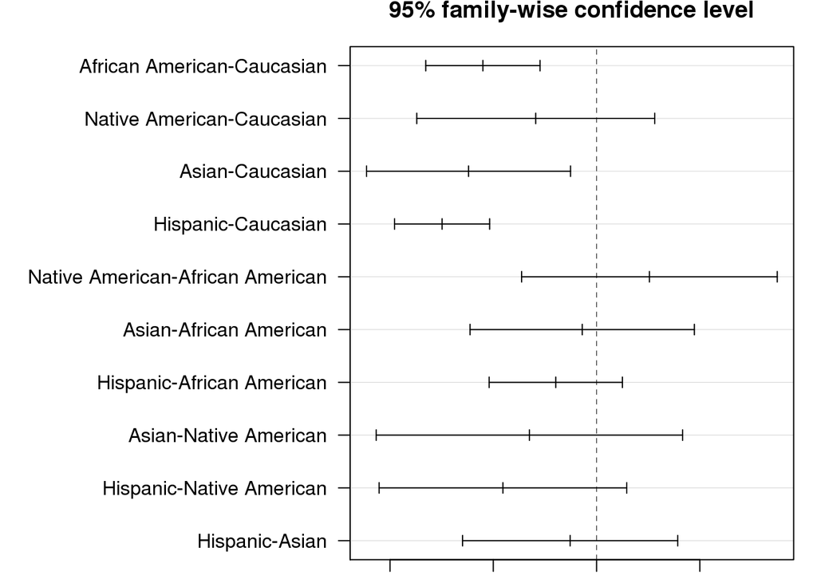

```r
opar <- par(no.readonly = TRUE)  # copy of current settings
par(mar =c(1, 15, 2, 1))
plot(CIs, las = 1)
```

```r
par(opar)                        # restore original settings
```

Evidence (p-value = $1.1904597\times 10^{-19}$) suggests a strong relationship between ethnicity and the estimated number of cigarettes an individual smokes per month. Post hoc comparisons suggest mean differences in the number of cigarettes smoked per month for African American and Caucasian, Asian and Caucasian, and Hispanic and Caucasian ethnic groups.

## Chi Square Tests

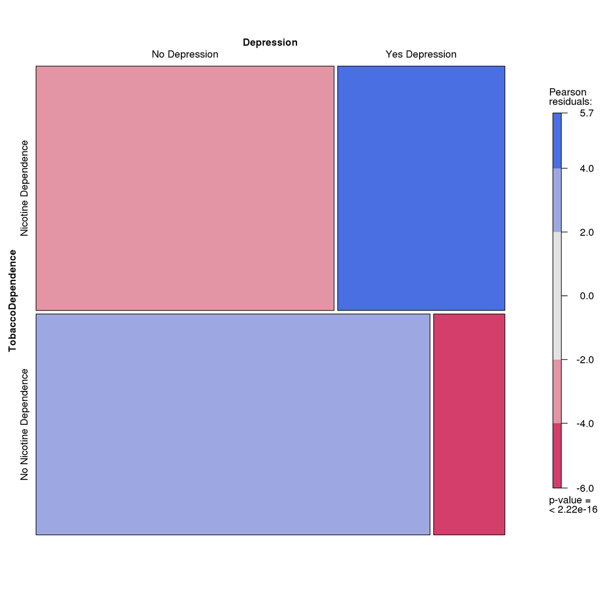

```r
library(vcd)
mosaic(~TobaccoDependence + Depression, data = nesarc.sub, shade = TRUE)
```

```r
xtabs(~TobaccoDependence + Depression, data = nesarc.sub)
```

```
                        Depression
TobaccoDependence        No Depression Yes Depression
  Nicotine Dependence              574            322
  No Nicotine Dependence           686            124
```

```r
T1 <- prop.table(xtabs(~TobaccoDependence + Depression, data = nesarc.sub), 1)
T1
```

```
                        Depression
TobaccoDependence        No Depression Yes Depression
  Nicotine Dependence        0.6406250      0.3593750
  No Nicotine Dependence     0.8469136      0.1530864
```

```r
CR <- chisq.test(nesarc.sub$TobaccoDependence, nesarc.sub$Depression)
CR
```

```
    Pearson's Chi-squared test with Yates' continuity correction

data:  nesarc.sub$TobaccoDependence and nesarc.sub$Depression
X-squared = 92.695, df = 1, p-value < 2.2e-16
```

A Chi Square test of independence suggest that among young adult smokers, those with past year nicotine dependence were more likely to have experiences major depression in their lifetime (35.9375%) compared to those without past year nicotine dependence (15.308642%), $\chi^2 = 92.6945346$, 1 df, *p* < 0.0001.

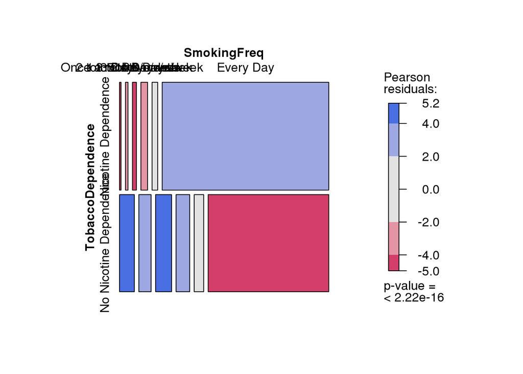

```r
mosaic(~TobaccoDependence + SmokingFreq, data = nesarc.sub, shade = TRUE)
```

```r
TA <- xtabs(~TobaccoDependence + SmokingFreq, data = nesarc.sub)
TA
```

```
                        SmokingFreq
TobaccoDependence        Once a month or less 2 to 3 Days/month
  Nicotine Dependence                       7                12
  No Nicotine Dependence                   64                53
                        SmokingFreq
TobaccoDependence        1 to 2 Days/week 3 to 4 Days/week
  Nicotine Dependence                  19               32
  No Nicotine Dependence               69               59
                        SmokingFreq
TobaccoDependence        5 to 6 Days/week Every Day
  Nicotine Dependence                  27       799
  No Nicotine Dependence               41       521
```

```r
T1 <- prop.table(xtabs(~TobaccoDependence + SmokingFreq, data = nesarc.sub), 1)
T1
```

```
                        SmokingFreq
TobaccoDependence        Once a month or less 2 to 3 Days/month
  Nicotine Dependence              0.00781250        0.01339286
  No Nicotine Dependence           0.07930607        0.06567534
                        SmokingFreq
TobaccoDependence        1 to 2 Days/week 3 to 4 Days/week
  Nicotine Dependence          0.02120536       0.03571429
  No Nicotine Dependence       0.08550186       0.07311029
                        SmokingFreq
TobaccoDependence        5 to 6 Days/week  Every Day
  Nicotine Dependence          0.03013393 0.89174107
  No Nicotine Dependence       0.05080545 0.64560099
```

```r
CR <- chisq.test(nesarc.sub$TobaccoDependence, nesarc.sub$SmokingFreq)
CR
```

```
    Pearson's Chi-squared test

data:  nesarc.sub$TobaccoDependence and nesarc.sub$SmokingFreq
X-squared = 165.27, df = 5, p-value < 2.2e-16
```

The Chi Square test of independence suggest there is an association between smoking frequency and tobacco dependence. To determine if there are significant differences among the six levels of smoking frequency requires one to examine $\binom{6}{2} =$ 15 possible differences with an appropriate $\alpha$ value to account for the multiple comparisons. Use the Bonferroni approach where $= 0.05/(15) = 0.0033333 to control the experiment-wise error rate.

```r
chisq.test(TA[, c(1, 2)]) # not significant
```

```
    Pearson's Chi-squared test with Yates' continuity correction

data:  TA[, c(1, 2)]
X-squared = 1.4349, df = 1, p-value = 0.231
```

```r
chisq.test(TA[, c(1, 3)]) # not significant
```

```
    Pearson's Chi-squared test with Yates' continuity correction

data:  TA[, c(1, 3)]
X-squared = 3.1428, df = 1, p-value = 0.07626
```

```r
chisq.test(TA[, c(1, 4)]) # significant
```

```
    Pearson's Chi-squared test with Yates' continuity correction

data:  TA[, c(1, 4)]
X-squared = 12.623, df = 1, p-value = 0.0003811
```

```r
chisq.test(TA[, c(1, 5)]) # significant
```

```
    Pearson's Chi-squared test with Yates' continuity correction

data:  TA[, c(1, 5)]
X-squared = 15.169, df = 1, p-value = 9.828e-05
```

```r
chisq.test(TA[, c(1, 6)]) # significant
```

```
    Pearson's Chi-squared test with Yates' continuity correction

data:  TA[, c(1, 6)]
X-squared = 68.925, df = 1, p-value < 2.2e-16
```

```r
chisq.test(TA[, c(2, 3)]) # not significant
```

```
    Pearson's Chi-squared test with Yates' continuity correction

data:  TA[, c(2, 3)]
X-squared = 0.074306, df = 1, p-value = 0.7852
```

```r
chisq.test(TA[, c(2, 4)]) # not significant
```

```
    Pearson's Chi-squared test with Yates' continuity correction

data:  TA[, c(2, 4)]
X-squared = 4.4318, df = 1, p-value = 0.03527
```

```r
chisq.test(TA[, c(2, 5)]) # not significant
```

```
    Pearson's Chi-squared test with Yates' continuity correction

data:  TA[, c(2, 5)]
X-squared = 6.2484, df = 1, p-value = 0.01243
```

```r
chisq.test(TA[, c(2, 6)]) # significant
```

```
    Pearson's Chi-squared test with Yates' continuity correction

data:  TA[, c(2, 6)]
X-squared = 43.461, df = 1, p-value = 4.325e-11
```

```r
chisq.test(TA[, c(3, 4)]) # not significant
```

```
    Pearson's Chi-squared test with Yates' continuity correction

data:  TA[, c(3, 4)]
X-squared = 3.407, df = 1, p-value = 0.06492
```

```r
chisq.test(TA[, c(3, 5)]) # not significant
```

```
    Pearson's Chi-squared test with Yates' continuity correction

data:  TA[, c(3, 5)]
X-squared = 5.2141, df = 1, p-value = 0.0224
```

```r
chisq.test(TA[, c(3, 6)]) # significant
```

```
    Pearson's Chi-squared test with Yates' continuity correction

data:  TA[, c(3, 6)]
X-squared = 49.797, df = 1, p-value = 1.705e-12
```

```r
chisq.test(TA[, c(4, 5)]) # not significant
```

```
    Pearson's Chi-squared test with Yates' continuity correction

data:  TA[, c(4, 5)]
X-squared = 0.17683, df = 1, p-value = 0.6741
```

```r
chisq.test(TA[, c(4, 6)]) # significant
```

```
    Pearson's Chi-squared test with Yates' continuity correction

data:  TA[, c(4, 6)]
X-squared = 21.59, df = 1, p-value = 3.376e-06
```

```r
chisq.test(TA[, c(5, 6)]) # significant
```

```
    Pearson's Chi-squared test with Yates' continuity correction

data:  TA[, c(5, 6)]
X-squared = 10.79, df = 1, p-value = 0.00102
```

There are significant differences between the percent of subjects that have nicotine dependence while smoking once a month or less and 3 to 4 Days/week, 5 to 6 Days/week, and Every Day. There are significant differences between percent of subjects that have nicotine dependence while smoking Every day and each of the less frequent smoking modes.

```r
library(moonBook)
out <- mytable(Depression + TobaccoDependence ~  Age + SmokingFreq + DailyCigsSmoked + Ethnicity + Sex +DaysSmoke + TotalCigsSmoked + CigsSmokedFac , data = nesarc.sub)
myhtml(out)
```

Descriptive Statistics stratified by Depression and TobaccoDependence

| Depression | No Depression |  |  | Yes Depression |  |  |
| --- | --- | --- | --- | --- | --- | --- |
| TobaccoDependence | Nicotine Dependence (N=574) | No Nicotine Dependence (N=686) | p | Nicotine Dependence (N=322) | No Nicotine Dependence (N=124) | p |
| Age | 21.5 ± 2.3 | 21.7 ± 2.1 | 0.145 | 21.5 ± 2.2 | 21.8 ± 2.2 | 0.205 |
| SmokingFreq |  |  | 0.000 |  |  | 0.000 |
| Once a month or less | 6 ( 1.0%) | 43 ( 6.3%) |  | 1 ( 0.3%) | 21 (16.9%) |  |
| 2 to 3 Days/month | 8 ( 1.4%) | 41 ( 6.0%) |  | 4 ( 1.2%) | 12 ( 9.7%) |  |
| 1 to 2 Days/week | 12 ( 2.1%) | 60 ( 8.8%) |  | 7 ( 2.2%) | 9 ( 7.3%) |  |
| 3 to 4 Days/week | 22 ( 3.8%) | 50 ( 7.3%) |  | 10 ( 3.1%) | 9 ( 7.3%) |  |
| 5 to 6 Days/week | 16 ( 2.8%) | 34 ( 5.0%) |  | 11 ( 3.4%) | 7 ( 5.6%) |  |
| Every Day | 510 (88.9%) | 455 (66.6%) |  | 289 (89.8%) | 66 (53.2%) |  |
| DailyCigsSmoked | 13.6 ± 9.0 | 9.0 ± 7.5 | 0.000 | 13.8 ± 9.5 | 7.3 ± 6.1 | 0.000 |
| Ethnicity |  |  | 0.000 |  |  | 0.053 |
| Caucasian | 377 (65.7%) | 402 (58.6%) |  | 214 (66.5%) | 67 (54.0%) |  |
| African American | 77 (13.4%) | 86 (12.5%) |  | 27 ( 8.4%) | 21 (16.9%) |  |
| Native American | 12 ( 2.1%) | 9 ( 1.3%) |  | 15 ( 4.7%) | 6 ( 4.8%) |  |
| Asian | 25 ( 4.4%) | 20 ( 2.9%) |  | 10 ( 3.1%) | 3 ( 2.4%) |  |
| Hispanic | 83 (14.5%) | 169 (24.6%) |  | 56 (17.4%) | 27 (21.8%) |  |
| Sex |  |  | 0.633 |  |  | 0.031 |
| Female | 263 (45.8%) | 304 (44.3%) |  | 194 (60.2%) | 89 (71.8%) |  |
| Male | 311 (54.2%) | 382 (55.7%) |  | 128 (39.8%) | 35 (28.2%) |  |
| DaysSmoke |  |  | 0.000 |  |  | 0.000 |
| 1 | 18 ( 3.1%) | 103 (15.1%) |  | 8 ( 2.5%) | 30 (24.2%) |  |
| 2.5 | 8 ( 1.4%) | 41 ( 6.0%) |  | 4 ( 1.2%) | 12 ( 9.7%) |  |
| 14 | 22 ( 3.8%) | 50 ( 7.3%) |  | 10 ( 3.1%) | 9 ( 7.3%) |  |
| 22 | 16 ( 2.8%) | 34 ( 5.0%) |  | 11 ( 3.4%) | 7 ( 5.6%) |  |
| 30 | 510 (88.9%) | 455 (66.6%) |  | 289 (89.8%) | 66 (53.2%) |  |
| TotalCigsSmoked | 394.9 ± 280.5 | 241.7 ± 239.6 | 0.000 | 403.9 ± 294.2 | 175.7 ± 197.0 | 0.000 |
| CigsSmokedFac |  |  | 0.000 |  |  | 0.000 |
| [1,90] | 69 (12.0%) | 258 (38.0%) |  | 40 (12.5%) | 62 (50.4%) |  |
| (90,300] | 241 (42.0%) | 262 (38.6%) |  | 132 (41.1%) | 43 (35.0%) |  |
| (300,600] | 224 (39.0%) | 139 (20.5%) |  | 122 (38.0%) | 18 (14.6%) |  |
| (600,2.94e+03] | 40 ( 7.0%) | 20 ( 2.9%) |  | 27 ( 8.4%) | 0 ( 0.0%) |  |